# Homework day 3

Barrett Bryson

1/11/2015

```r
library(ISLR)
library (MASS)
```

**Problem 7**  
**A)**  
Point 1: 3 units Point 2: 2 units Point 3: 3.16227 units Point 4: 2.23606 units Point 5: 1.41421 units Point 6: 1.73205 units  
**B)**  
With K=1 the prediction would be red because the sole nearest point.  
**C)**  
With K=3 the prediction would be red beacuse of the three closest points two are red and one is green.  
**D)**  
We would expect a smaller k values so that it closer follows the points.

**Problem 9**  
**A)** Qualitative:Name, Origin  
Quantative: cylinders, displacement,horsepower, weight, acceleration, year  
**B)**

```r
range(Auto$cylinders)
```

```
## [1] 3 8
```

```r
range(Auto$displacement)
```

```
## [1]  68 455
```

```r
range(Auto$horsepower)
```

```
## [1]  46 230
```

```r
range(Auto$weight)
```

```
## [1] 1613 5140
```

```r
range(Auto$acceleration)
```

```
## [1]  8.0 24.8
```

```r
range(Auto$year)
```

```
## [1] 70 82
```

**C)**

```r
mean(Auto$cylinders)
```

```
## [1] 5.471939
```

```r
sd(Auto$cylinders)
```

```
## [1] 1.705783
```

```r
mean(Auto$displacement)
```

```
## [1] 194.412
```

```r
sd(Auto$displacement)
```

```
## [1] 104.644
```

```r
mean(Auto$horsepower)
```

```
## [1] 104.4694
```

```r
sd(Auto$horsepower)
```

```
## [1] 38.49116
```

```r
mean(Auto$weight)
```

```
## [1] 2977.584
```

```r
sd(Auto$weight)
```

```
## [1] 849.4026
```

```r
mean(Auto$acceleration)
```

```
## [1] 15.54133
```

```r
sd(Auto$acceleration)
```

```
## [1] 2.758864
```

```r
mean(Auto$year)
```

```
## [1] 75.97959
```

```r
sd(Auto$year)
```

```
## [1] 3.683737
```

**D)**

```r
ReducedAuto = Auto[-c(10:85),]

range(ReducedAuto$cylinders)
```

```
## [1] 3 8
```

```r
mean(ReducedAuto$cylinders)
```

```
## [1] 5.373418
```

```r
sd(ReducedAuto$cylinders)
```

```
## [1] 1.654179
```

```r
range(ReducedAuto$displacement)
```

```
## [1]  68 455
```

```r
mean(ReducedAuto$displacement)
```

```
## [1] 187.2405
```

```r
sd(ReducedAuto$displacement)
```

```
## [1] 99.67837
```

```r
range(ReducedAuto$horsepower)
```

```
## [1]  46 230
```

```r
mean(ReducedAuto$horsepower)
```

```
## [1] 100.7215
```

```r
sd(ReducedAuto$horsepower)
```

```
## [1] 35.70885
```

```r
range(ReducedAuto$weight)
```

```
## [1] 1649 4997
```

```r
mean(ReducedAuto$weight)
```

```
## [1] 2935.972
```

```r
sd(ReducedAuto$weight)
```

```
## [1] 811.3002
```

```r
range(ReducedAuto$acceleration)
```

```
## [1]  8.5 24.8
```

```r
mean(ReducedAuto$acceleration)
```

```
## [1] 15.7269
```

```r
sd(ReducedAuto$acceleration)
```

```
## [1] 2.693721
```

```r
range(ReducedAuto$year)
```

```
## [1] 70 82
```

```r
mean(ReducedAuto$year)
```

```
## [1] 77.14557
```

```r
sd(ReducedAuto$year)
```

```
## [1] 3.106217
```

**E)**

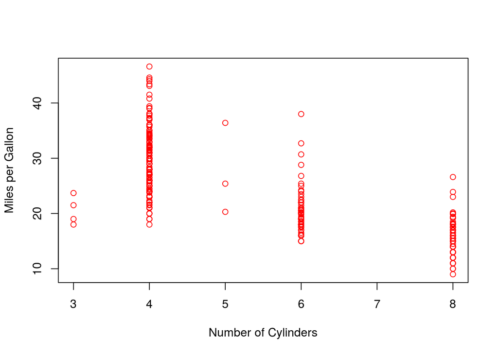

Graph shows a general negative trend between the number of cylinders and the miles per gallon of the car.

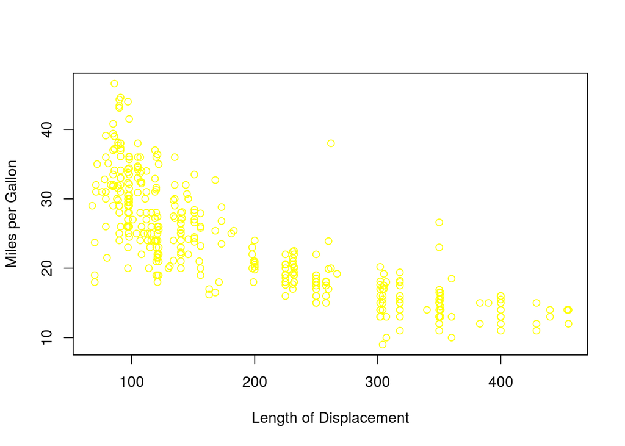

Graph shows a general negative trend between the length of displacement and the miles per gallon of the car.

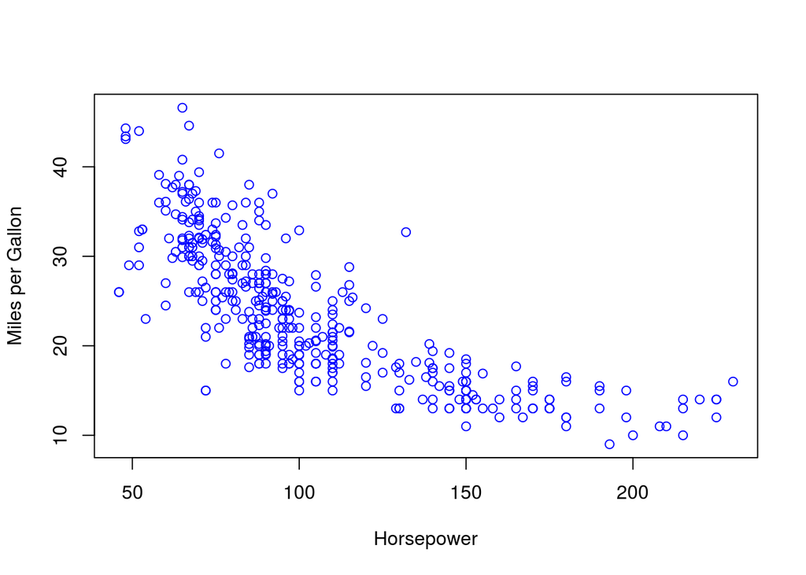

Graph shows a general negative trend between the horsepower of the engine and the miles per gallon of the car.

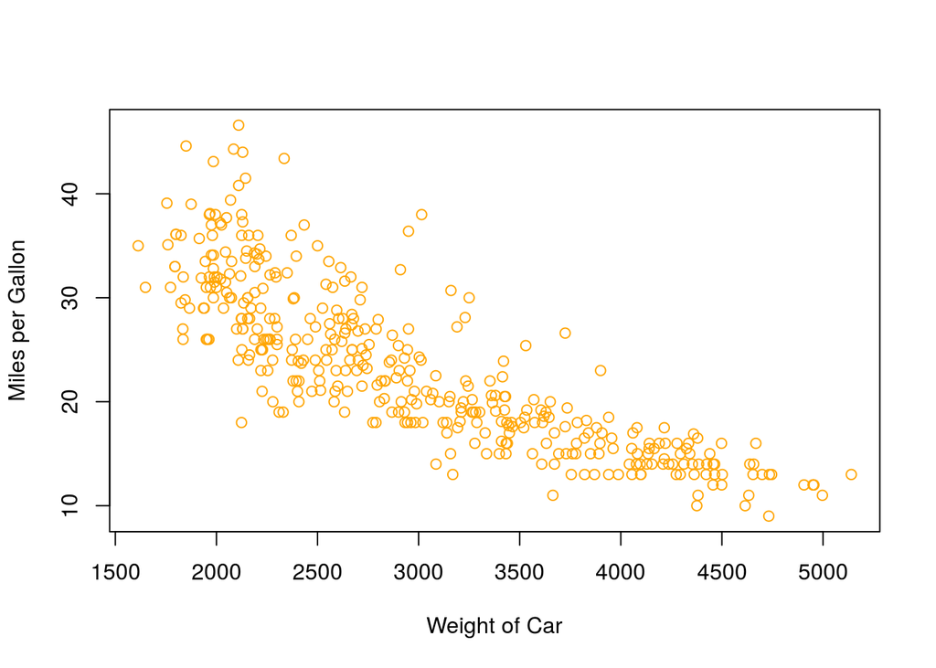

Graph shows a general negative trend between the weight of the car and the miles per gallon of the car.

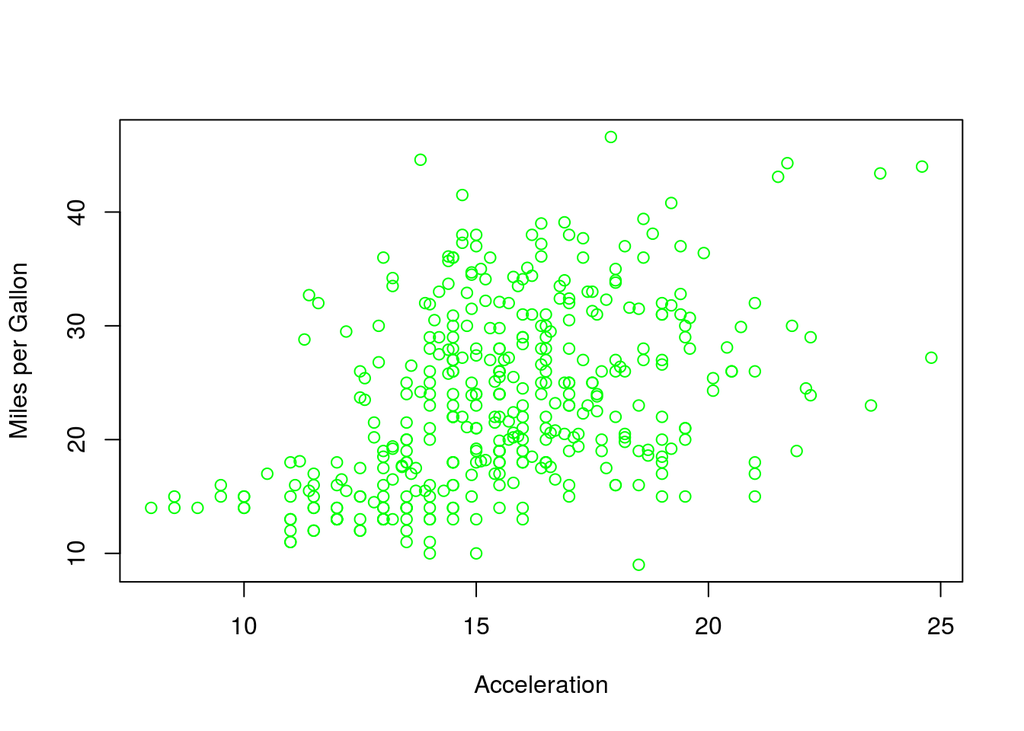

Graph shows a general positive trend between the acceleration and the miles per gallon of the car.

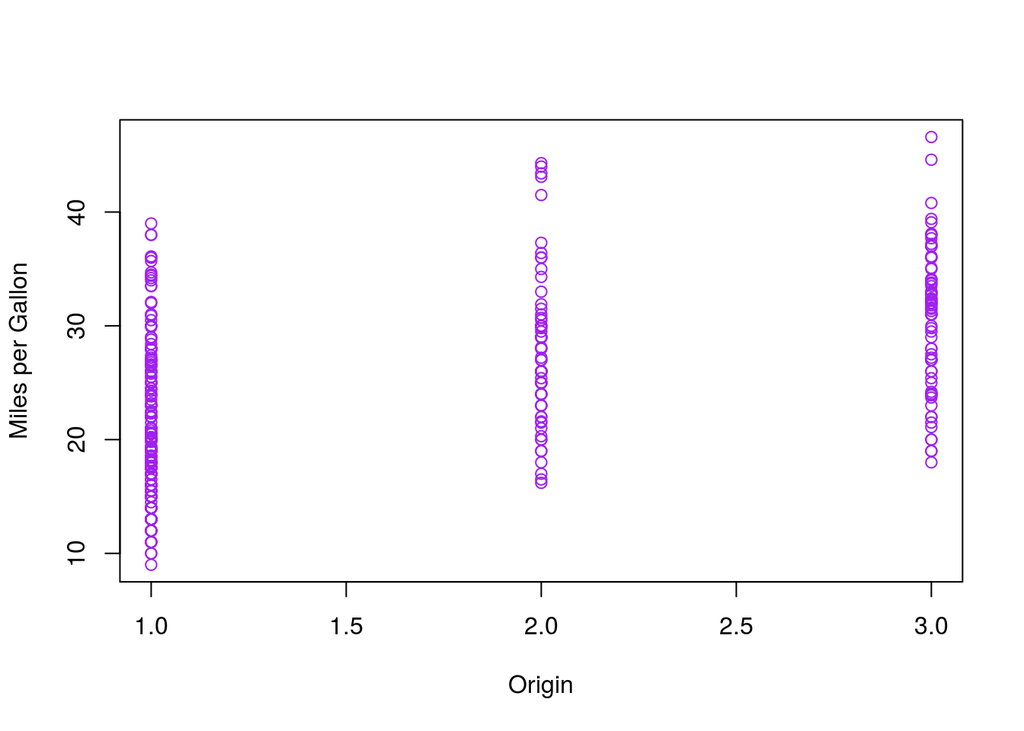

Graph shows that japaneese cars tend to do the best, European are second best and American tend to be the worst, in terms of mpg.  
**F)**  
I would suggest the inclusion of drag. The different body shapes of different models of cars can lead to difference in the friction due to air.

**Problem 10**  
**A)**  
This data set has 14 columns and 506 rows.  
Description of Columns:  
crim: per capita crime rate by town.  
zn: proportion of residential land zoned for lots over 25,000 sq.ft.  
indus: proportion of non-retail business acres per town.  
chas: Charles River dummy variable (= 1 if tract bounds river; 0 otherwise).  
nox: nitrogen oxides concentration (parts per 10 million).  
rm: average number of rooms per dwelling.  
age: proportion of owner-occupied units built prior to 1940.  
dis: weighted mean of distances to five Boston employment centres.  
rad: index of accessibility to radial highways.  
tax: full-value property-tax rate per $10,000.  
ptratio: pupil-teacher ratio by town.  
black: 1000(Bk - 0.63)^2 where Bk is the proportion of blacks by town.  
lstat: lower status of the population (percent).  
medv: median value of owner-occupied homes in $1000s.  
**B)**

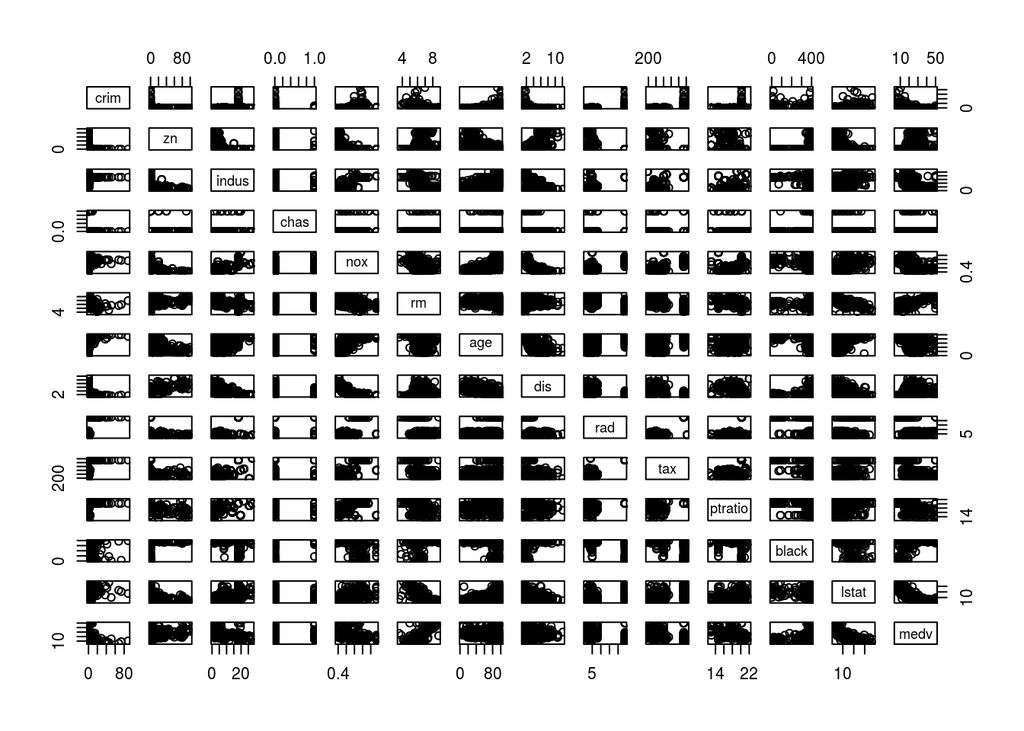

This allows us to quickly spot correlations in the data